# Web scraping MyAnimeList.net

11/13/2016

## Web scraping MyAnimeList.net

MyAnimeList.net http://MyAnimeList.net is the world's most active online anime and manga community and database.

- Scraping website
- Exploratory Data Analysis
- Regression model

## Web Scraping

- Completed using scrapy.
- Scraped 89244 reviews and info about 5953 anime.
- Another ~6000 anime don't have any review were skipped.
- clean up data while scraping,
- store data in correct format – Json vs. csv -> list vs. data.frame.

## Total Number of Reviews

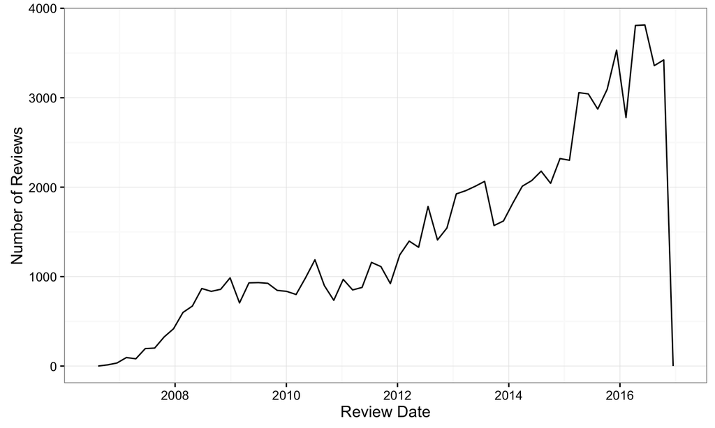

## Trend of most reviewed anime

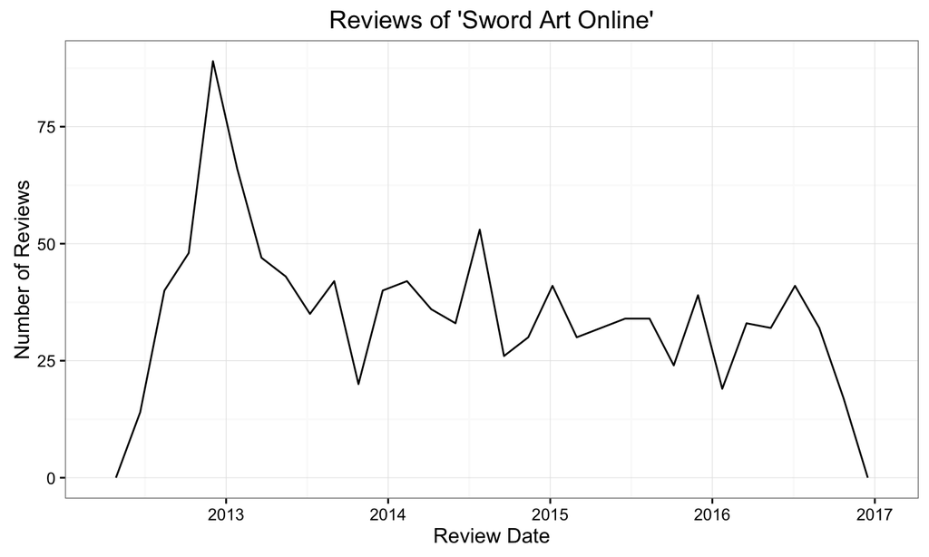

Airing started in Summer 2012, ended in Dec 2012. A short film aired in Dec 2013 and its sequel air in Summer 2014.

## Anime Info EDA

```r
length(AnimeInfo)
```

```
## [1] 5953
```

```r
names(AnimeInfo[[1]])
```

```
##  [1] "anime_title"      "anime_status"     "anime_popularity"
##  [4] "anime_studios"    "anime_genres"     "anime_favorites"
##  [7] "anime_synopsis"   "anime_aired"      "anime_premiered"
## [10] "anime_related"    "anime_mainactors" "anime_producers"
## [13] "anime_score"      "anime_ranked"     "anime_staff"
## [16] "anime_rating"     "anime_background" "anime_episodes"
## [19] "anime_type"       "anime_members"
```

## Anime Info EDA 2

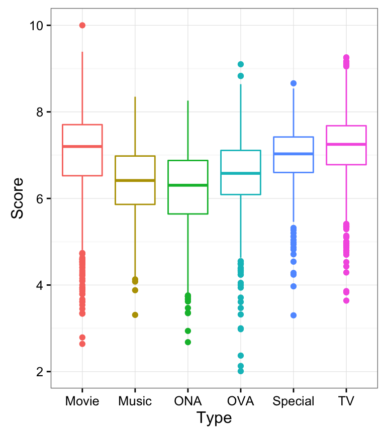

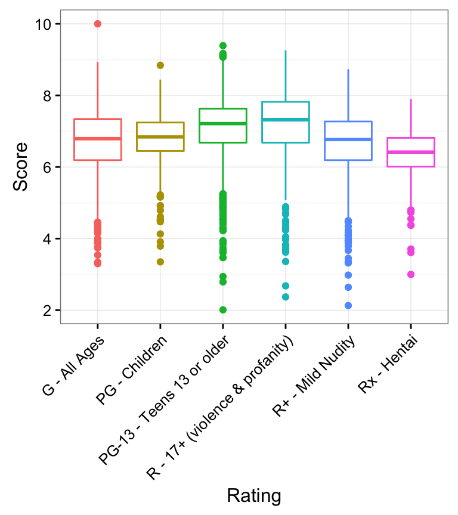

## Network graph of 100 anime

[interactive chart not shown]

## Regression Model - predicting anime score

Aim: to build to model to predict score of an anime

Difficulties: Only viewers, favorites are numerical variables, other variables such as Rating, Type, Director, Actors, Musicians etc. are all categorical variables.

Tried to create dummy variables: using a list of directors who won an award in last 20 years and divide the director into 2 groups.

## Model 1, adjusted R-squared value = 0.289

```r
model <- glm(Score ~ Award_Director + Viewer + Favorite + Type + Rating,
             data = AnimeInfo_df)
#summary(model)
```

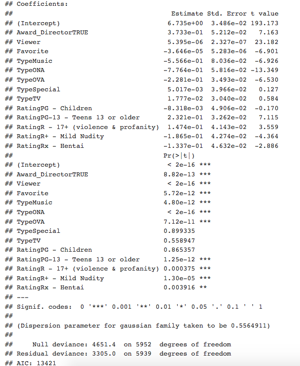

Summary model 1

## check model1 assumptions

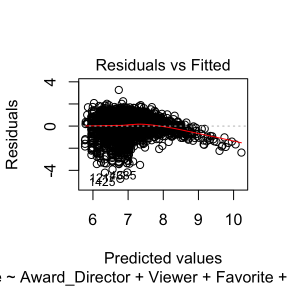

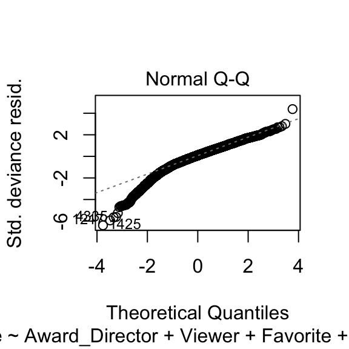

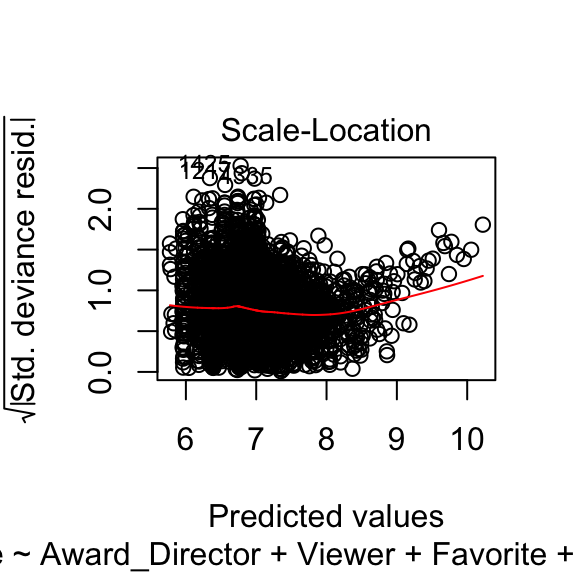

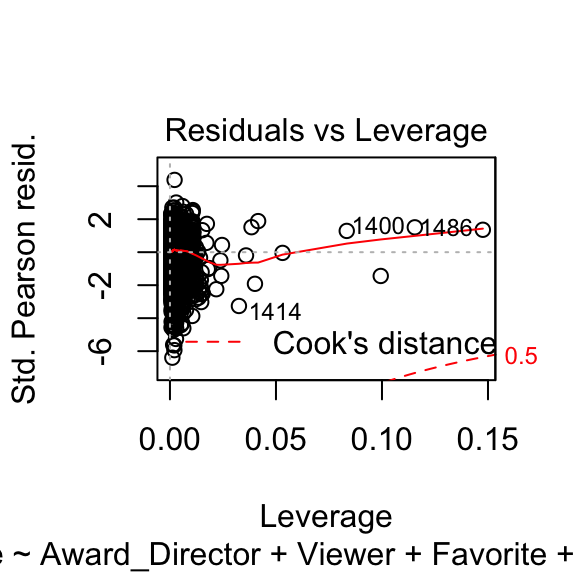

## check vif

```r
vif(model)
```

```
##                    GVIF Df GVIF^(1/(2*Df))
## Award_Director 1.025117  1        1.012481
## Viewer         3.089501  1        1.757698
## Favorite       2.654953  1        1.629403
## Type           1.853266  5        1.063638
## Rating         1.751659  5        1.057657
```

## check avplots

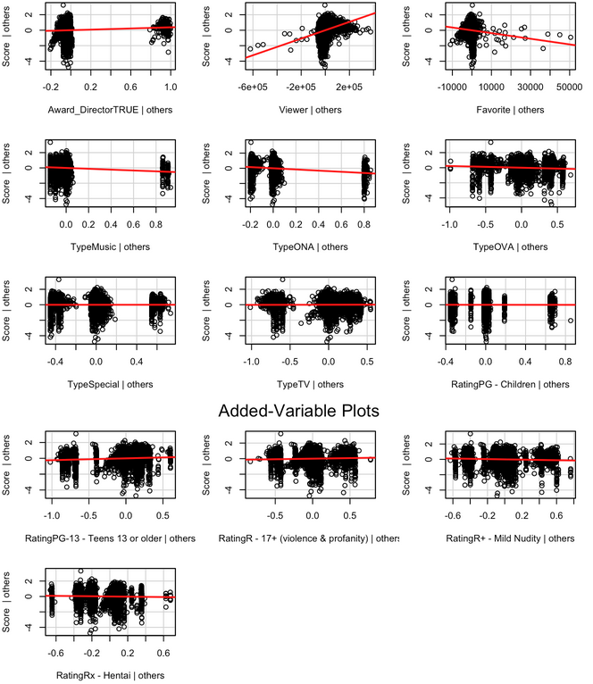

Avplots model 1

## Future work

- Normalize viewer/favorites against time since release;
- Use number of favorites on staff/actor pages to turn Director, Actor etc. into continuous variable.